[figure not shown]

# Artificial Intelligence

## CA4: MACHINE LEARNING

## Teacher: Dr. Fadaei

### Student Name: Mohammadali Shakerdargah

### Student Number: 810098002

### Purpose:

```
In this project we are going to use "scikit-library" to perform machine learning algorithms on given data so that we can fit a model to estimate each vehicle's price.
```

### What we did in this Project:

[output not shown]

```python
!nvidia-smi -L
```

```
NVIDIA-SMI has failed because it couldn't communicate with the NVIDIA driver. Make sure that the latest NVIDIA driver is installed and running.
```

```python
!pip install hazm
!pip install https://github.com/sobhe/hazm/archive/master.zip --upgrade
!pip install arabic-reshaper
!pip install python-bidi
```

```
  Using cached https://github.com/sobhe/hazm/archive/master.zip
```

```python
from __future__ import unicode_literals
from hazm import *
import pandas as pd
from numpy import *
import math
import copy
import operator
import matplotlib.pyplot as plt
import arabic_reshaper
from bidi.algorithm import get_display
import sklearn
from sklearn import feature_selection
from sklearn import metrics
from sklearn.preprocessing import MinMaxScaler
from sklearn.feature_extraction.text import (CountVectorizer,
                                             TfidfVectorizer,
                                             TfidfTransformer)
from sklearn.model_selection import train_test_split

from sklearn.tree import DecisionTreeRegressor
from sklearn.neighbors import KNeighborsRegressor
from sklearn.linear_model import LinearRegression
from sklearn.ensemble import RandomForestRegressor
```

```python
from google.colab import drive
drive.mount('/content/drive')
```

```python
# data = pd.read_csv("/content/drive/MyDrive/Colab_Documents/AI/CA4/vehicles.csv")
data = pd.read_csv("vehicles.csv")
data
```

|  | brand | category | created_at | description | image_count | mileage | price | title | year |
| --- | --- | --- | --- | --- | --- | --- | --- | --- | --- |
| 0 | NaN | heavy | Tuesday 07PM | سریال 43j$NUMبدون شکستگی سه حلقه لاستیک نو یک ... | 4 | NaN | -1 | لودر کاتر پیلار 950 | NaN |
| 1 | سایر | light | Wednesday 04AM | دوگانه ال پی جی بیمه با تخفیف دارد \nتودوزی نو... | 3 | 180000.0 | -1 | پاترول شش سیلندر چهار درب | 1366 |
| 2 | پژو ۴۰۵::Peugeot 405 | light | Wednesday 11AM | پژو 2000فنی تازه تعمیر بدنه بدون خطو خش تخیف ب... | 0 | 290000.0 | 8500000 | پژو مدل 81 مشکی | 1381 |
| 3 | نیسان::Nissan | light | Wednesday 01PM | سلام.\nماشین کاملا سالم همه چی فابریک متور زد ... | 3 | 175000.0 | 19500000 | پاترول 2در | 1372 |
| 4 | سمند::Samand | light | Thursday 07AM | سمند ال ایکس بدون رنگ تمامی سرویس ها انجام شده... | 4 | 80000.0 | 23900000 | سمند دوگانه کارخانه | 1391 |
| ... | ... | ... | ... | ... | ... | ... | ... | ... | ... |
| 130438 | NaN | heavy | Wednesday 03PM | بادسان فوق بیرنگ سفید رنگ بیمه تابرج 3.96 تخفی... | 2 | NaN | 48000000 | بادسان 8b14 مدل83 | NaN |
| 130439 | NaN | heavy | Wednesday 06PM | باسلام .تراکتورازصفری دست خودم بوده.سالم.ودارا... | 4 | NaN | -1 | تراکتورگلدونی ۲۳۸ایتالیا | NaN |
| 130440 | سمند::Samand | light | Wednesday 06PM | ماشینم تصادفیه با خریدار توافق میکنم سر قیمتش | 3 | 20000.0 | -1 | خودرو سمند تصادفی مدل92 | 1392 |
| 130441 | پراید صندوق‌دار::Pride | light | Thursday 03PM | سند۲ برگ،بیمه تا برج$NUMتخفیفات بیمه 15 سال،مع... | 4 | 123000.0 | 6900000 | پراید 79 بسیار سالم | 1379 |
| 130442 | پراید صندوق‌دار::Pride | light | Friday 04PM | پراید دوگانه کارخانه میباشد و کم کارکرد.روکش .... | 3 | 43000.0 | 17400000 | پراید دوگانه کارخانه مدل93 | 1393 |

130443 rows × 9 columns

```python
data.info()
```

```
<class 'pandas.core.frame.DataFrame'>
RangeIndex: 130443 entries, 0 to 130442
Data columns (total 9 columns):
 #   Column       Non-Null Count   Dtype
---  ------       --------------   -----
 0   brand        120451 non-null  object
 1   category     130443 non-null  object
 2   created_at   130443 non-null  object
 3   description  130443 non-null  object
 4   image_count  130443 non-null  int64
 5   mileage      120451 non-null  float64
 6   price        130443 non-null  int64
 7   title        130443 non-null  object
 8   year         120451 non-null  object
dtypes: float64(1), int64(2), object(6)
memory usage: 9.0+ MB
```

# Phase 1: Preprocessing and Visualization

# Question 1 answer: Information Gain and preprocesses

- First I got rid of those NAN rows and rows without a price.
- Then, I changed brands from categorical to numerical values (We only had 26 specific brands).
- After erasing NAN rows and changing brands from categorical to numerical, I decided to cleanse my data. In order to cleanse data I used "hazm" library.
  - it is formal that it is better to work with root of each word. It tells us that prefixes and postfixes are not that necessary for us to participate them in our process.And sometimes they may even reduce our accuracy because all versions of a word are telling us the same thing and almost same info,So we will use 2 methods called "Stemming" and "lemmatization". these two methods share the same goal, and the goal is to remove unnecessary prefixes and postfixes from a word. I prefered to use "lemmatization" because found it beter to use so we won't have (آسمان -> آسم) . It works
    - lemmatizer.lemmatize('می‌روم') -> 'رفت#رو'
  - I could have gone with "Stemming" too and it works like this:
    - like this: stemmer.stem('کتاب‌ها') -> 'کتاب'
- Then, I tried to change category of the cars into numerical which containes only light cars -> 0
- I scaled "Mileage" with MinMaxScaler so that we wouldn't have our data in a big range.
- I numerized "created at" and it got 168 specific and unique values.
- I changed -Object- variables to numerical (I had to change some rows in column 'year' because it had punctuations in them

### Getting rid of NAN rows and rows without a price.

```python
data = data[pd.notnull(data['brand'])]
data = data.reset_index(drop=True)
i = data[(data.price == -1)].index
data = data.drop(data.index[[i]])
data = data.reset_index(drop=True)
data.info()
data
```

```
<class 'pandas.core.frame.DataFrame'>
RangeIndex: 103799 entries, 0 to 103798
Data columns (total 9 columns):
 #   Column       Non-Null Count   Dtype
---  ------       --------------   -----
 0   brand        103799 non-null  object
 1   category     103799 non-null  object
 2   created_at   103799 non-null  object
 3   description  103799 non-null  object
 4   image_count  103799 non-null  int64
 5   mileage      103799 non-null  float64
 6   price        103799 non-null  int64
 7   title        103799 non-null  object
 8   year         103799 non-null  object
dtypes: float64(1), int64(2), object(6)
memory usage: 7.1+ MB
```

|  | brand | category | created_at | description | image_count | mileage | price | title | year |
| --- | --- | --- | --- | --- | --- | --- | --- | --- | --- |
| 0 | پژو ۴۰۵::Peugeot 405 | light | Wednesday 11AM | پژو 2000فنی تازه تعمیر بدنه بدون خطو خش تخیف ب... | 0 | 290000.0 | 8500000 | پژو مدل 81 مشکی | 1381 |
| 1 | نیسان::Nissan | light | Wednesday 01PM | سلام.\nماشین کاملا سالم همه چی فابریک متور زد ... | 3 | 175000.0 | 19500000 | پاترول 2در | 1372 |
| 2 | سمند::Samand | light | Thursday 07AM | سمند ال ایکس بدون رنگ تمامی سرویس ها انجام شده... | 4 | 80000.0 | 23900000 | سمند دوگانه کارخانه | 1391 |
| 3 | پژو ۴۰۵::Peugeot 405 | light | Thursday 08AM | بیمه یکسال ده سال تخفیف دور رنگ شاسی پلمپ سالم | 3 | 125000.0 | 8500000 | پژو405 مدل84 | 1384 |
| 4 | ام‌وی‌ام::MVM | light | Thursday 08AM | ام وی ام چهار سیلندر مدل 93 فنی سالم بدون رنگ ... | 2 | 11000.0 | 18500000 | ام وی ام 110 چهار سیلندر | 1393 |
| ... | ... | ... | ... | ... | ... | ... | ... | ... | ... |
| 103794 | پژو ۴۰۵::Peugeot 405 | light | Monday 01PM | پژو GLX تاکسی گردشی مدل ۱۳۹۰ بسیار کم کارکرد\... | 1 | 120000.0 | 25900000 | پژو 405 GLX تاکسی گردشی | 1390 |
| 103795 | تندر ۹۰::Tondar 90 | light | Tuesday 02PM | فوق‌العاده سالم بدون رنگ دزدگیر ماجیکار شیشه ه... | 2 | 173000.0 | 30000000 | ال۹۰ E2 | 1390 |
| 103796 | پراید صندوق‌دار::Pride | light | Tuesday 05PM | مدل 84 تمیز. بدون رنگ. سیستم صوتی. رینگ و لاست... | 3 | 140000.0 | 11000000 | پراید مدل 84 بدون رنگ | 1384 |
| 103797 | پراید صندوق‌دار::Pride | light | Thursday 03PM | سند۲ برگ،بیمه تا برج$NUMتخفیفات بیمه 15 سال،مع... | 4 | 123000.0 | 6900000 | پراید 79 بسیار سالم | 1379 |
| 103798 | پراید صندوق‌دار::Pride | light | Friday 04PM | پراید دوگانه کارخانه میباشد و کم کارکرد.روکش .... | 3 | 43000.0 | 17400000 | پراید دوگانه کارخانه مدل93 | 1393 |

103799 rows × 9 columns

### Numerizing "brand"

```python
def brandCategorizer(data, brand, categories):
    for i in range(len(data[brand])):
        brand_i = data[brand][i]
        if(brand_i in categories):
            data[brand][i] = categories.get(brand_i)
    return data
```

```python
uniqueCategories = data['brand'].unique()
categories ={}
for i in range(len(uniqueCategories)):
    categories[uniqueCategories[i]] = i
for category in categories:
    print("Mapped: ",category," -> ", categories.get(category))
data = brandCategorizer(data, 'brand', categories)
data
```

```
Mapped:  پژو ۴۰۵::Peugeot 405  ->  0
Mapped:  نیسان::Nissan  ->  1
Mapped:  سمند::Samand  ->  2
Mapped:  ام‌وی‌ام::MVM  ->  3
Mapped:  پراید صندوق‌دار::Pride  ->  4
Mapped:  پراید هاچ‌بک::Pride  ->  5
Mapped:  سایر  ->  6
Mapped:  پژو ۲۰۶‍::Peugeot 206  ->  7
Mapped:  پیکان::Peykan  ->  8
Mapped:  پژو پارس::Peugeot Pars  ->  9
Mapped:  پژو روآ / آر‌دی::RD/ROA  ->  10
Mapped:  پژو ۲۰۶‍ صندوق‌دار::Peugeot 206  ->  11
Mapped:  تیبا::Tiba  ->  12
Mapped:  وانت  ->  13
Mapped:  کیا::Kia  ->  14
Mapped:  رنو::Renault  ->  15
Mapped:  رانا::Runna  ->  16
Mapped:  دوو::Daewoo  ->  17
Mapped:  هیوندای (غیره)::Hyundai  ->  18
Mapped:  زانتیا::Citroen Xantia  ->  19
Mapped:  تندر ۹۰::Tondar 90  ->  20
Mapped:  تویوتا::Toyota  ->  21
Mapped:  لیفان::Lifan  ->  22
Mapped:  بنز::Mercedes-Benz  ->  23
Mapped:  هیوندای سوناتا::Hyundai Sonata  ->  24
Mapped:  بی‌ام‌و::BMW  ->  25
```

|  | brand | category | created_at | description | image_count | mileage | price | title | year |
| --- | --- | --- | --- | --- | --- | --- | --- | --- | --- |
| 0 | 0 | light | Wednesday 11AM | پژو 2000فنی تازه تعمیر بدنه بدون خطو خش تخیف ب... | 0 | 290000.0 | 8500000 | پژو مدل 81 مشکی | 1381 |
| 1 | 1 | light | Wednesday 01PM | سلام.\nماشین کاملا سالم همه چی فابریک متور زد ... | 3 | 175000.0 | 19500000 | پاترول 2در | 1372 |
| 2 | 2 | light | Thursday 07AM | سمند ال ایکس بدون رنگ تمامی سرویس ها انجام شده... | 4 | 80000.0 | 23900000 | سمند دوگانه کارخانه | 1391 |
| 3 | 0 | light | Thursday 08AM | بیمه یکسال ده سال تخفیف دور رنگ شاسی پلمپ سالم | 3 | 125000.0 | 8500000 | پژو405 مدل84 | 1384 |
| 4 | 3 | light | Thursday 08AM | ام وی ام چهار سیلندر مدل 93 فنی سالم بدون رنگ ... | 2 | 11000.0 | 18500000 | ام وی ام 110 چهار سیلندر | 1393 |
| ... | ... | ... | ... | ... | ... | ... | ... | ... | ... |
| 103794 | 0 | light | Monday 01PM | پژو GLX تاکسی گردشی مدل ۱۳۹۰ بسیار کم کارکرد\... | 1 | 120000.0 | 25900000 | پژو 405 GLX تاکسی گردشی | 1390 |
| 103795 | 20 | light | Tuesday 02PM | فوق‌العاده سالم بدون رنگ دزدگیر ماجیکار شیشه ه... | 2 | 173000.0 | 30000000 | ال۹۰ E2 | 1390 |
| 103796 | 4 | light | Tuesday 05PM | مدل 84 تمیز. بدون رنگ. سیستم صوتی. رینگ و لاست... | 3 | 140000.0 | 11000000 | پراید مدل 84 بدون رنگ | 1384 |
| 103797 | 4 | light | Thursday 03PM | سند۲ برگ،بیمه تا برج$NUMتخفیفات بیمه 15 سال،مع... | 4 | 123000.0 | 6900000 | پراید 79 بسیار سالم | 1379 |
| 103798 | 4 | light | Friday 04PM | پراید دوگانه کارخانه میباشد و کم کارکرد.روکش .... | 3 | 43000.0 | 17400000 | پراید دوگانه کارخانه مدل93 | 1393 |

103799 rows × 9 columns

```python
def dataCleanse(df,col):
    normalizer = Normalizer()
    lemmatizer = Lemmatizer()

    for i in range(len(df[col])):
        df[col][i] = normalizer.normalize(df[col][i])

    punctuations = set('''!()-[]{};:'"\,٬٫،<>./?@#$%٪^&*×ـ+=_~.؟؛«»|…''') #Set of unnecessary punctuations
    for i in range(len(df[col])):
        without_punctuations = ""
        for char in df[col][i]:
            if(char not in punctuations):
                without_punctuations = without_punctuations + char
        df[col][i] = word_tokenize(without_punctuations)

    stops = set(stopwords_list()) #List of unnecessary words
    for i in range(len(df[col])):
        wordsWithoutStops = ""
        for j in range(len(df[col][i])):
            if(df[col][i][j] not in stops):
                wordsWithoutStops = wordsWithoutStops + " " + (lemmatizer.lemmatize(df[col][i][j]))
        df[col][i] = wordsWithoutStops
    return df
```

### Text preprocessing for "description" and "title"

```python
data['text'] = data['description']+ data['title']
data = data.drop('description', 1)
data = data.drop('title', 1)
data
```

|  | brand | category | created_at | image_count | mileage | price | year | text |
| --- | --- | --- | --- | --- | --- | --- | --- | --- |
| 0 | 0 | light | Wednesday 11AM | 0 | 290000.0 | 8500000 | 1381 | پژو 2000فنی تازه تعمیر بدنه بدون خطو خش تخیف ب... |
| 1 | 1 | light | Wednesday 01PM | 3 | 175000.0 | 19500000 | 1372 | سلام.\nماشین کاملا سالم همه چی فابریک متور زد ... |
| 2 | 2 | light | Thursday 07AM | 4 | 80000.0 | 23900000 | 1391 | سمند ال ایکس بدون رنگ تمامی سرویس ها انجام شده... |
| 3 | 0 | light | Thursday 08AM | 3 | 125000.0 | 8500000 | 1384 | بیمه یکسال ده سال تخفیف دور رنگ شاسی پلمپ سالم... |
| 4 | 3 | light | Thursday 08AM | 2 | 11000.0 | 18500000 | 1393 | ام وی ام چهار سیلندر مدل 93 فنی سالم بدون رنگ ... |
| ... | ... | ... | ... | ... | ... | ... | ... | ... |
| 103794 | 0 | light | Monday 01PM | 1 | 120000.0 | 25900000 | 1390 | پژو GLX تاکسی گردشی مدل ۱۳۹۰ بسیار کم کارکرد\... |
| 103795 | 20 | light | Tuesday 02PM | 2 | 173000.0 | 30000000 | 1390 | فوق‌العاده سالم بدون رنگ دزدگیر ماجیکار شیشه ه... |
| 103796 | 4 | light | Tuesday 05PM | 3 | 140000.0 | 11000000 | 1384 | مدل 84 تمیز. بدون رنگ. سیستم صوتی. رینگ و لاست... |
| 103797 | 4 | light | Thursday 03PM | 4 | 123000.0 | 6900000 | 1379 | سند۲ برگ،بیمه تا برج$NUMتخفیفات بیمه 15 سال،مع... |
| 103798 | 4 | light | Friday 04PM | 3 | 43000.0 | 17400000 | 1393 | پراید دوگانه کارخانه میباشد و کم کارکرد.روکش .... |

103799 rows × 8 columns

```python
data_cleansed = dataCleanse(data, 'text')
```

```python
data_cleansed
```

|  | brand | category | created_at | image_count | mileage | price | year | text |
| --- | --- | --- | --- | --- | --- | --- | --- | --- |
| 0 | 0 | light | Wednesday 11AM | 0 | 290000.0 | 8500000 | 1381 | پژو ۲۰۰۰ فن تازه تعمیر بدنه خطو خش تخیف بیمه ... |
| 1 | 1 | light | Wednesday 01PM | 3 | 175000.0 | 19500000 | 1372 | سلام ماشین سالم چی فابریک متور زد#زن ژاپن لاس... |
| 2 | 2 | light | Thursday 07AM | 4 | 80000.0 | 23900000 | 1391 | سمند ال ایکس رنگ سرویس‌ها انجام لاستیک ۹۰ تشک... |
| 3 | 0 | light | Thursday 08AM | 3 | 125000.0 | 8500000 | 1384 | بیمه یکسال ده سال تخفیف رنگ شاسی پلمپ سالمپژو... |
| 4 | 3 | light | Thursday 08AM | 2 | 11000.0 | 18500000 | 1393 | ام ام سیلندر مدل ۹۳ فن سالم رنگ تخفیف بیمه دا... |
| ... | ... | ... | ... | ... | ... | ... | ... | ... |
| 103794 | 0 | light | Monday 01PM | 1 | 120000.0 | 25900000 | 1390 | پژو GLX تاکسی گردش مدل ۱۳۹۰ کارکرد نو استفاده... |
| 103795 | 20 | light | Tuesday 02PM | 2 | 173000.0 | 30000000 | 1390 | فوق‌العاده سالم رنگ دزدگیر ماجیکار شیشه دود ر... |
| 103796 | 4 | light | Tuesday 05PM | 3 | 140000.0 | 11000000 | 1384 | مدل ۸۴ تمیز رنگ سیستم صوت رینگ لاستیک لوازم ب... |
| 103797 | 4 | light | Thursday 03PM | 4 | 123000.0 | 6900000 | 1379 | سند۲ برگ بیمه برجNUMتخفیفات بیمه ۱۵ سال معاین... |
| 103798 | 4 | light | Friday 04PM | 3 | 43000.0 | 17400000 | 1393 | پراید دوگانه کارخانه میباشد کارکرد روکش ظبط ف... |

103799 rows × 8 columns

### Numerizing "category"

```python
def categorizer(data, brand, categories):
    for i in range(len(data[brand])):
        brand_i = data[brand][i]
        if(brand_i in categories):
            data[brand][i] = categories.get(brand_i)
    return data
```

```python
unique_Categories_cars = data_cleansed['category'].unique()
categories_cars ={}
for i in range(len(unique_Categories_cars)):
    categories_cars[unique_Categories_cars[i]] = i
for category in categories_cars:
    print("Mapped: ",category," -> ", categories_cars.get(category))
data_cleansed = categorizer(data_cleansed, 'category', categories_cars)
data_cleansed
```

```
Mapped:  light  ->  0
```

|  | brand | category | created_at | image_count | mileage | price | year | text |
| --- | --- | --- | --- | --- | --- | --- | --- | --- |
| 0 | 0 | 0 | Wednesday 11AM | 0 | 290000.0 | 8500000 | 1381 | پژو ۲۰۰۰ فن تازه تعمیر بدنه خطو خش تخیف بیمه ... |
| 1 | 1 | 0 | Wednesday 01PM | 3 | 175000.0 | 19500000 | 1372 | سلام ماشین سالم چی فابریک متور زد#زن ژاپن لاس... |
| 2 | 2 | 0 | Thursday 07AM | 4 | 80000.0 | 23900000 | 1391 | سمند ال ایکس رنگ سرویس‌ها انجام لاستیک ۹۰ تشک... |
| 3 | 0 | 0 | Thursday 08AM | 3 | 125000.0 | 8500000 | 1384 | بیمه یکسال ده سال تخفیف رنگ شاسی پلمپ سالمپژو... |
| 4 | 3 | 0 | Thursday 08AM | 2 | 11000.0 | 18500000 | 1393 | ام ام سیلندر مدل ۹۳ فن سالم رنگ تخفیف بیمه دا... |
| ... | ... | ... | ... | ... | ... | ... | ... | ... |
| 103794 | 0 | 0 | Monday 01PM | 1 | 120000.0 | 25900000 | 1390 | پژو GLX تاکسی گردش مدل ۱۳۹۰ کارکرد نو استفاده... |
| 103795 | 20 | 0 | Tuesday 02PM | 2 | 173000.0 | 30000000 | 1390 | فوق‌العاده سالم رنگ دزدگیر ماجیکار شیشه دود ر... |
| 103796 | 4 | 0 | Tuesday 05PM | 3 | 140000.0 | 11000000 | 1384 | مدل ۸۴ تمیز رنگ سیستم صوت رینگ لاستیک لوازم ب... |
| 103797 | 4 | 0 | Thursday 03PM | 4 | 123000.0 | 6900000 | 1379 | سند۲ برگ بیمه برجNUMتخفیفات بیمه ۱۵ سال معاین... |
| 103798 | 4 | 0 | Friday 04PM | 3 | 43000.0 | 17400000 | 1393 | پراید دوگانه کارخانه میباشد کارکرد روکش ظبط ف... |

103799 rows × 8 columns

### "mileage" on scale of 0 to 1

```python
MMScaler = MinMaxScaler()
data_cleansed[['mileage']] = MMScaler.fit_transform(data_cleansed[['mileage']])
data_cleansed
```

|  | brand | category | created_at | image_count | mileage | price | year | text |
| --- | --- | --- | --- | --- | --- | --- | --- | --- |
| 0 | 0 | 0 | Wednesday 11AM | 0 | 0.580 | 8500000 | 1381 | پژو ۲۰۰۰ فن تازه تعمیر بدنه خطو خش تخیف بیمه ... |
| 1 | 1 | 0 | Wednesday 01PM | 3 | 0.350 | 19500000 | 1372 | سلام ماشین سالم چی فابریک متور زد#زن ژاپن لاس... |
| 2 | 2 | 0 | Thursday 07AM | 4 | 0.160 | 23900000 | 1391 | سمند ال ایکس رنگ سرویس‌ها انجام لاستیک ۹۰ تشک... |
| 3 | 0 | 0 | Thursday 08AM | 3 | 0.250 | 8500000 | 1384 | بیمه یکسال ده سال تخفیف رنگ شاسی پلمپ سالمپژو... |
| 4 | 3 | 0 | Thursday 08AM | 2 | 0.022 | 18500000 | 1393 | ام ام سیلندر مدل ۹۳ فن سالم رنگ تخفیف بیمه دا... |
| ... | ... | ... | ... | ... | ... | ... | ... | ... |
| 103794 | 0 | 0 | Monday 01PM | 1 | 0.240 | 25900000 | 1390 | پژو GLX تاکسی گردش مدل ۱۳۹۰ کارکرد نو استفاده... |
| 103795 | 20 | 0 | Tuesday 02PM | 2 | 0.346 | 30000000 | 1390 | فوق‌العاده سالم رنگ دزدگیر ماجیکار شیشه دود ر... |
| 103796 | 4 | 0 | Tuesday 05PM | 3 | 0.280 | 11000000 | 1384 | مدل ۸۴ تمیز رنگ سیستم صوت رینگ لاستیک لوازم ب... |
| 103797 | 4 | 0 | Thursday 03PM | 4 | 0.246 | 6900000 | 1379 | سند۲ برگ بیمه برجNUMتخفیفات بیمه ۱۵ سال معاین... |
| 103798 | 4 | 0 | Friday 04PM | 3 | 0.086 | 17400000 | 1393 | پراید دوگانه کارخانه میباشد کارکرد روکش ظبط ف... |

103799 rows × 8 columns

### Numerizing "created at"

```python
unique_created_at = data_cleansed['created_at'].unique()
categories_created_at ={}
for i in range(len(unique_created_at)):
    categories_created_at[unique_created_at[i]] = i
for category in categories_created_at:
    print("Mapped: ",category," -> ", categories_created_at.get(category))
data_cleansed = categorizer(data_cleansed, 'created_at', categories_created_at)
data_cleansed
```

```
Mapped:  Wednesday 11AM  ->  0
Mapped:  Wednesday 01PM  ->  1
Mapped:  Thursday 07AM  ->  2
Mapped:  Thursday 08AM  ->  3
Mapped:  Thursday 09AM  ->  4
Mapped:  Friday 04AM  ->  5
Mapped:  Friday 12PM  ->  6
Mapped:  Saturday 12PM  ->  7
Mapped:  Saturday 01PM  ->  8
Mapped:  Sunday 08AM  ->  9
Mapped:  Sunday 09AM  ->  10
Mapped:  Sunday 11AM  ->  11
Mapped:  Sunday 02PM  ->  12
Mapped:  Sunday 05PM  ->  13
Mapped:  Tuesday 07AM  ->  14
Mapped:  Tuesday 07PM  ->  15
Mapped:  Tuesday 08PM  ->  16
Mapped:  Wednesday 02PM  ->  17
Mapped:  Wednesday 04PM  ->  18
Mapped:  Wednesday 06PM  ->  19
Mapped:  Thursday 10AM  ->  20
Mapped:  Thursday 12PM  ->  21
Mapped:  Friday 10AM  ->  22
Mapped:  Sunday 07AM  ->  23
Mapped:  Sunday 03PM  ->  24
Mapped:  Monday 06AM  ->  25
Mapped:  Monday 08AM  ->  26
Mapped:  Monday 09AM  ->  27
Mapped:  Monday 07PM  ->  28
Mapped:  Tuesday 03PM  ->  29
Mapped:  Tuesday 04PM  ->  30
Mapped:  Wednesday 09AM  ->  31
Mapped:  Thursday 05AM  ->  32
Mapped:  Thursday 11AM  ->  33
Mapped:  Thursday 02PM  ->  34
Mapped:  Thursday 07PM  ->  35
Mapped:  Friday 06AM  ->  36
Mapped:  Friday 08AM  ->  37
Mapped:  Friday 09AM  ->  38
Mapped:  Friday 01PM  ->  39
```

[output cut: 113 more lines]

```
Mapped:  Sunday 12AM  ->  153
Mapped:  Monday 10PM  ->  154
Mapped:  Wednesday 02AM  ->  155
Mapped:  Thursday 03AM  ->  156
Mapped:  Saturday 01AM  ->  157
Mapped:  Wednesday 12AM  ->  158
Mapped:  Saturday 10PM  ->  159
Mapped:  Friday 12AM  ->  160
Mapped:  Saturday 03AM  ->  161
Mapped:  Tuesday 12AM  ->  162
Mapped:  Friday 03AM  ->  163
Mapped:  Thursday 02AM  ->  164
Mapped:  Friday 02AM  ->  165
Mapped:  Monday 01AM  ->  166
Mapped:  Saturday 02AM  ->  167
```

|  | brand | category | created_at | image_count | mileage | price | year | text |
| --- | --- | --- | --- | --- | --- | --- | --- | --- |
| 0 | 0 | 0 | 0 | 0 | 0.580 | 8500000 | 1381 | پژو ۲۰۰۰ فن تازه تعمیر بدنه خطو خش تخیف بیمه ... |
| 1 | 1 | 0 | 1 | 3 | 0.350 | 19500000 | 1372 | سلام ماشین سالم چی فابریک متور زد#زن ژاپن لاس... |
| 2 | 2 | 0 | 2 | 4 | 0.160 | 23900000 | 1391 | سمند ال ایکس رنگ سرویس‌ها انجام لاستیک ۹۰ تشک... |
| 3 | 0 | 0 | 3 | 3 | 0.250 | 8500000 | 1384 | بیمه یکسال ده سال تخفیف رنگ شاسی پلمپ سالمپژو... |
| 4 | 3 | 0 | 3 | 2 | 0.022 | 18500000 | 1393 | ام ام سیلندر مدل ۹۳ فن سالم رنگ تخفیف بیمه دا... |
| ... | ... | ... | ... | ... | ... | ... | ... | ... |
| 103794 | 0 | 0 | 120 | 1 | 0.240 | 25900000 | 1390 | پژو GLX تاکسی گردش مدل ۱۳۹۰ کارکرد نو استفاده... |
| 103795 | 20 | 0 | 49 | 2 | 0.346 | 30000000 | 1390 | فوق‌العاده سالم رنگ دزدگیر ماجیکار شیشه دود ر... |
| 103796 | 4 | 0 | 50 | 3 | 0.280 | 11000000 | 1384 | مدل ۸۴ تمیز رنگ سیستم صوت رینگ لاستیک لوازم ب... |
| 103797 | 4 | 0 | 90 | 4 | 0.246 | 6900000 | 1379 | سند۲ برگ بیمه برجNUMتخفیفات بیمه ۱۵ سال معاین... |
| 103798 | 4 | 0 | 75 | 3 | 0.086 | 17400000 | 1393 | پراید دوگانه کارخانه میباشد کارکرد روکش ظبط ف... |

103799 rows × 8 columns

```python
data_cleansed
```

|  | brand | category | created_at | image_count | mileage | price | year | text |
| --- | --- | --- | --- | --- | --- | --- | --- | --- |
| 0 | 0 | 0 | 0 | 0 | 0.580 | 8500000 | 1381 | پژو ۲۰۰۰ فن تازه تعمیر بدنه خطو خش تخیف بیمه ... |
| 1 | 1 | 0 | 1 | 3 | 0.350 | 19500000 | 1372 | سلام ماشین سالم چی فابریک متور زد#زن ژاپن لاس... |
| 2 | 2 | 0 | 2 | 4 | 0.160 | 23900000 | 1391 | سمند ال ایکس رنگ سرویس‌ها انجام لاستیک ۹۰ تشک... |
| 3 | 0 | 0 | 3 | 3 | 0.250 | 8500000 | 1384 | بیمه یکسال ده سال تخفیف رنگ شاسی پلمپ سالمپژو... |
| 4 | 3 | 0 | 3 | 2 | 0.022 | 18500000 | 1393 | ام ام سیلندر مدل ۹۳ فن سالم رنگ تخفیف بیمه دا... |
| ... | ... | ... | ... | ... | ... | ... | ... | ... |
| 103794 | 0 | 0 | 120 | 1 | 0.240 | 25900000 | 1390 | پژو GLX تاکسی گردش مدل ۱۳۹۰ کارکرد نو استفاده... |
| 103795 | 20 | 0 | 49 | 2 | 0.346 | 30000000 | 1390 | فوق‌العاده سالم رنگ دزدگیر ماجیکار شیشه دود ر... |
| 103796 | 4 | 0 | 50 | 3 | 0.280 | 11000000 | 1384 | مدل ۸۴ تمیز رنگ سیستم صوت رینگ لاستیک لوازم ب... |
| 103797 | 4 | 0 | 90 | 4 | 0.246 | 6900000 | 1379 | سند۲ برگ بیمه برجNUMتخفیفات بیمه ۱۵ سال معاین... |
| 103798 | 4 | 0 | 75 | 3 | 0.086 | 17400000 | 1393 | پراید دوگانه کارخانه میباشد کارکرد روکش ظبط ف... |

103799 rows × 8 columns

```python
data_cleansed.to_csv('data_cleansed.csv')
```

```python
data_cleansed_2 = copy.deepcopy(data_cleansed)
data_cleansed_2
```

|  | brand | category | created_at | image_count | mileage | price | year | text |
| --- | --- | --- | --- | --- | --- | --- | --- | --- |
| 0 | 0 | 0 | 0 | 0 | 0.580 | 8500000 | 1381 | پژو ۲۰۰۰ فن تازه تعمیر بدنه خطو خش تخیف بیمه ... |
| 1 | 1 | 0 | 1 | 3 | 0.350 | 19500000 | 1372 | سلام ماشین سالم چی فابریک متور زد#زن ژاپن لاس... |
| 2 | 2 | 0 | 2 | 4 | 0.160 | 23900000 | 1391 | سمند ال ایکس رنگ سرویس‌ها انجام لاستیک ۹۰ تشک... |
| 3 | 0 | 0 | 3 | 3 | 0.250 | 8500000 | 1384 | بیمه یکسال ده سال تخفیف رنگ شاسی پلمپ سالمپژو... |
| 4 | 3 | 0 | 3 | 2 | 0.022 | 18500000 | 1393 | ام ام سیلندر مدل ۹۳ فن سالم رنگ تخفیف بیمه دا... |
| ... | ... | ... | ... | ... | ... | ... | ... | ... |
| 103794 | 0 | 0 | 120 | 1 | 0.240 | 25900000 | 1390 | پژو GLX تاکسی گردش مدل ۱۳۹۰ کارکرد نو استفاده... |
| 103795 | 20 | 0 | 49 | 2 | 0.346 | 30000000 | 1390 | فوق‌العاده سالم رنگ دزدگیر ماجیکار شیشه دود ر... |
| 103796 | 4 | 0 | 50 | 3 | 0.280 | 11000000 | 1384 | مدل ۸۴ تمیز رنگ سیستم صوت رینگ لاستیک لوازم ب... |
| 103797 | 4 | 0 | 90 | 4 | 0.246 | 6900000 | 1379 | سند۲ برگ بیمه برجNUMتخفیفات بیمه ۱۵ سال معاین... |
| 103798 | 4 | 0 | 75 | 3 | 0.086 | 17400000 | 1393 | پراید دوگانه کارخانه میباشد کارکرد روکش ظبط ف... |

103799 rows × 8 columns

# Objects to Numerics

```python
data_cleansed_2.info()

data_cleansed_2['brand'] = data_cleansed_2.brand.astype(float)
data_cleansed_2['category'] = data_cleansed_2.category.astype(float)
data_cleansed_2['created_at'] = data_cleansed_2.created_at.astype(float)
punctuations = set('''!()-[]{};:'"\,٬٫،<>./?@#$%٪^&*×ـ+=_~.؟؛«»|…''') #Set of unnecessary punctuations
for i in range(len(data_cleansed_2['year'])):
    without_punctuations = ""
    for char in data_cleansed_2['year'][i]:
        if(char not in punctuations):
            without_punctuations = without_punctuations + char
    data_cleansed_2['year'][i] = without_punctuations
data_cleansed_2['year'] = data_cleansed_2.year.astype(float)

data_cleansed_2.info()
```

```
<class 'pandas.core.frame.DataFrame'>
RangeIndex: 103799 entries, 0 to 103798
Data columns (total 8 columns):
 #   Column       Non-Null Count   Dtype
---  ------       --------------   -----
 0   brand        103799 non-null  object
 1   category     103799 non-null  object
 2   created_at   103799 non-null  object
 3   image_count  103799 non-null  int64
 4   mileage      103799 non-null  float64
 5   price        103799 non-null  int64
 6   year         103799 non-null  object
 7   text         103799 non-null  object
dtypes: float64(1), int64(2), object(5)
memory usage: 6.3+ MB
```

```
<class 'pandas.core.frame.DataFrame'>
RangeIndex: 103799 entries, 0 to 103798
Data columns (total 8 columns):
 #   Column       Non-Null Count   Dtype
---  ------       --------------   -----
 0   brand        103799 non-null  float64
 1   category     103799 non-null  float64
 2   created_at   103799 non-null  float64
 3   image_count  103799 non-null  int64
 4   mileage      103799 non-null  float64
 5   price        103799 non-null  int64
 6   year         103799 non-null  float64
 7   text         103799 non-null  object
dtypes: float64(5), int64(2), object(1)
memory usage: 6.3+ MB
```

```python
data_cleansed_2_withOut_price = copy.deepcopy(data_cleansed_2)
data_cleansed_2_withOut_price = data_cleansed_2_withOut_price.drop(columns = ['price'])
data_cleansed_2_withOut_price
```

|  | brand | category | created_at | image_count | mileage | year | text |
| --- | --- | --- | --- | --- | --- | --- | --- |
| 0 | 0.0 | 0.0 | 0.0 | 0 | 0.580 | 1381.0 | پژو ۲۰۰۰ فن تازه تعمیر بدنه خطو خش تخیف بیمه ... |
| 1 | 1.0 | 0.0 | 1.0 | 3 | 0.350 | 1372.0 | سلام ماشین سالم چی فابریک متور زد#زن ژاپن لاس... |
| 2 | 2.0 | 0.0 | 2.0 | 4 | 0.160 | 1391.0 | سمند ال ایکس رنگ سرویس‌ها انجام لاستیک ۹۰ تشک... |
| 3 | 0.0 | 0.0 | 3.0 | 3 | 0.250 | 1384.0 | بیمه یکسال ده سال تخفیف رنگ شاسی پلمپ سالمپژو... |
| 4 | 3.0 | 0.0 | 3.0 | 2 | 0.022 | 1393.0 | ام ام سیلندر مدل ۹۳ فن سالم رنگ تخفیف بیمه دا... |
| ... | ... | ... | ... | ... | ... | ... | ... |
| 103794 | 0.0 | 0.0 | 120.0 | 1 | 0.240 | 1390.0 | پژو GLX تاکسی گردش مدل ۱۳۹۰ کارکرد نو استفاده... |
| 103795 | 20.0 | 0.0 | 49.0 | 2 | 0.346 | 1390.0 | فوق‌العاده سالم رنگ دزدگیر ماجیکار شیشه دود ر... |
| 103796 | 4.0 | 0.0 | 50.0 | 3 | 0.280 | 1384.0 | مدل ۸۴ تمیز رنگ سیستم صوت رینگ لاستیک لوازم ب... |
| 103797 | 4.0 | 0.0 | 90.0 | 4 | 0.246 | 1379.0 | سند۲ برگ بیمه برجNUMتخفیفات بیمه ۱۵ سال معاین... |
| 103798 | 4.0 | 0.0 | 75.0 | 3 | 0.086 | 1393.0 | پراید دوگانه کارخانه میباشد کارکرد روکش ظبط ف... |

103799 rows × 7 columns

```python
data_cleansed_2_withOut_price_and_text = copy.deepcopy(data_cleansed_2_withOut_price)
data_cleansed_2_withOut_price_and_text = data_cleansed_2_withOut_price_and_text.drop(columns = ['text'])
```

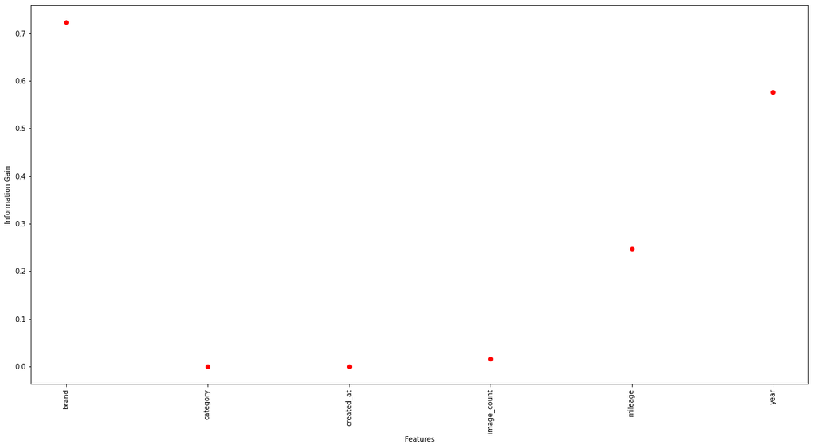

```python
features = list(data_cleansed_2_withOut_price_and_text.columns.values)
plt.figure(figsize = (20,10))
plt.plot(sklearn.feature_selection.mutual_info_classif(data_cleansed_2_withOut_price_and_text, data_cleansed_2['price']), 'ro')
plt.xticks(arange(len(features)), features, rotation = 90)
plt.xlabel('Features')
plt.ylabel('Information Gain')
plt.show()
```

Information gain is the reduction in entropy or surprise by transforming a dataset and is often used in training decision trees. Information gain is calculated by comparing the entropy of the dataset before and after a transformation. We can see that we can omit "category" and "created_at" because they have no gain

# Question 2 answer: Categorical Feature

In this question I will answer why do we need numerical feature instead of categorical feature. In machine learniong we work with numbers not texts, So in order to perform machine learning algorithms, we need to change categorical to numerical features. There are ways we can numeric our categorical features:

- Approach 1: Label Encoding

  ```
    Our approach to encoding categorical values is to use a technique called label encoding. Label encoding is simply converting each value in a column to a number. For example, the body_style column contains 5 different values. We could choose to encode it like this:
    Mapped:  Wednesday 04AM  ->  0
    Mapped:  Wednesday 11AM  ->  1
    Mapped:  Wednesday 01PM  ->  2
    Mapped:  Thursday 07AM  ->  3
    Mapped:  Thursday 08AM  ->  4
    Mapped:  Thursday 09AM  ->  5
    Mapped:  Friday 04AM  ->  6
    Mapped:  Friday 12PM  ->  7
    Mapped:  Saturday 06AM  ->  8
    Mapped:  Saturday 12PM  ->  9
    Mapped:  Saturday 01PM  ->  10
    Mapped:  Sunday 08AM  ->  11
    Mapped:  Sunday 09AM  ->  12
    Mapped:  Sunday 11AM  ->  13
    ...
  ```

- Approach 2: One Hot Encoding

  ```
    Label encoding has the advantage that it is straightforward but it has the disadvantage that the numeric values can be “misinterpreted” by the algorithms. For example, the value of 0 is obviously less than the value of 4 but does that really correspond to the data set in real life? Does a wagon have “4X” more weight in our calculation than the convertible? In this example, I don’t think so.

    A common alternative approach is called one hot encoding (but also goes by several different names shown below). Despite the different names, the basic strategy is to convert each category value into a new column and assigns a 1 or 0 (True/False) value to the column. This has the benefit of not weighting a value improperly but does have the downside of adding more columns to the data set.
  ```

### Resource: https://pbpython.com/categorical-encoding.html

# Question 3 answer: Feature extraction from text using CountVectorizer & Tf-idf Vectorizer

Vectorization is the general process of turning a collection of text documents into numerical feature vectors. This specific strategy (tokenization, counting and normalization) is called the Bag of Words or “Bag of n-grams” representation. Documents are described by word occurrences while completely ignoring the relative position information of the words in the document.

Below figure can show our text feature

[figure not shown]

We can see that we cannot work with this data for our processing, so we will have to change this feature to a numerical feature, we can use Count vectorizer or Tf-idf vectorizer.

- Example of TF-IDF Vectorizer:

```python
import pandas as pd
from sklearn.feature_extraction.text import TfidfTransformer as TfidfVectorizer
from sklearn.feature_extraction.text import CountVectorizer
dataset = [
    "I enjoy reading about Machine Learning and Machine Learning is my PhD subject",
    "I would enjoy a walk in the park",
    "I was reading in the library"]
tfIdfTransformer = TfidfTransformer(use_idf=True)
countVectorizer = CountVectorizer()
wordCount = countVectorizer.fit_transform(dataset)
newTfIdf = tfIdfTransformer.fit_transform(wordCount)
df = pd.DataFrame(newTfIdf[0].T.todense(), index=countVectorizer.get_feature_names(), columns=["TF-IDF"])
df = df.sort_values('TF-IDF', ascending=False)
print (df.head(10))
```

```
            TF-IDF
machine   0.513720
learning  0.513720
about     0.256860
subject   0.256860
phd       0.256860
and       0.256860
my        0.256860
is        0.256860
reading   0.195349
enjoy     0.195349
```

- Example of Count Vectorizer:

```python
from sklearn.feature_extraction.text import (CountVectorizer,
                                             TfidfVectorizer,
                                             TfidfTransformer)
corpus = ["The greatest thing of life is love.",
          "Love is great, it's great to be loved.",
          "Is love the greatest thing?",
          "I love lasagna for 1000 times as df gt re wa df gh yt re wwq rgth rhrds aef"]
vectorizer = CountVectorizer(analyzer='word', ngram_range=(1, 1), max_features=15)
vectorized = vectorizer.fit_transform(corpus)
df = pd.DataFrame(vectorized.toarray(),
                  index=['sentence '+str(i)
                   for i in range(1, 1+len(corpus))],
                  columns=vectorizer.get_feature_names())
df
```

|  | 1000 | df | great | greatest | is | love | of | re | rgth | rhrds | the | thing | times | to | wa |
| --- | --- | --- | --- | --- | --- | --- | --- | --- | --- | --- | --- | --- | --- | --- | --- |
| sentence 1 | 0 | 0 | 0 | 1 | 1 | 1 | 1 | 0 | 0 | 0 | 1 | 1 | 0 | 0 | 0 |
| sentence 2 | 0 | 0 | 2 | 0 | 1 | 1 | 0 | 0 | 0 | 0 | 0 | 0 | 0 | 1 | 0 |
| sentence 3 | 0 | 0 | 0 | 1 | 1 | 1 | 0 | 0 | 0 | 0 | 1 | 1 | 0 | 0 | 0 |
| sentence 4 | 1 | 2 | 0 | 0 | 0 | 1 | 0 | 2 | 1 | 1 | 0 | 0 | 1 | 0 | 1 |

Now we will perform Algorithms on our dataset

```python
text_all_col = []
for i in range(len(data_cleansed_2['text'])):
    text_all_col.append(data_cleansed_2['text'][i])
```

```python
data_cleansed_3 = copy.deepcopy(data_cleansed_2)
data_cleansed_3_withOut_price_and_text = copy.deepcopy(data_cleansed_2_withOut_price_and_text)
data_cleansed_3_withOut_price_and_text
```

|  | brand | category | created_at | image_count | mileage | year |
| --- | --- | --- | --- | --- | --- | --- |
| 0 | 0.0 | 0.0 | 0.0 | 0 | 0.580 | 1381.0 |
| 1 | 1.0 | 0.0 | 1.0 | 3 | 0.350 | 1372.0 |
| 2 | 2.0 | 0.0 | 2.0 | 4 | 0.160 | 1391.0 |
| 3 | 0.0 | 0.0 | 3.0 | 3 | 0.250 | 1384.0 |
| 4 | 3.0 | 0.0 | 3.0 | 2 | 0.022 | 1393.0 |
| ... | ... | ... | ... | ... | ... | ... |
| 103794 | 0.0 | 0.0 | 120.0 | 1 | 0.240 | 1390.0 |
| 103795 | 20.0 | 0.0 | 49.0 | 2 | 0.346 | 1390.0 |
| 103796 | 4.0 | 0.0 | 50.0 | 3 | 0.280 | 1384.0 |
| 103797 | 4.0 | 0.0 | 90.0 | 4 | 0.246 | 1379.0 |
| 103798 | 4.0 | 0.0 | 75.0 | 3 | 0.086 | 1393.0 |

103799 rows × 6 columns

```python
vectorizer = CountVectorizer(analyzer='word', ngram_range=(1, 1), max_features=200)
vectorized = vectorizer.fit_transform(text_all_col)
df_vec = pd.DataFrame(vectorized.toarray(),
                  index=[str(i-1)
                   for i in range(1, 1+len(text_all_col))],
                  columns=[str(i-1)
                   for i in range(1, 1+len(vectorizer.get_feature_names()))])
df_vec
```

|  | 0 | 1 | 2 | 3 | 4 | 5 | 6 | 7 | 8 | 9 | ... | 190 | 191 | 192 | 193 | 194 | 195 | 196 | 197 | 198 | 199 |
| --- | --- | --- | --- | --- | --- | --- | --- | --- | --- | --- | --- | --- | --- | --- | --- | --- | --- | --- | --- | --- | --- |
| 0 | 0 | 0 | 0 | 0 | 0 | 0 | 0 | 0 | 0 | 0 | ... | 0 | 0 | 0 | 0 | 0 | 0 | 0 | 0 | 0 | 0 |
| 1 | 0 | 0 | 0 | 0 | 0 | 0 | 0 | 0 | 0 | 0 | ... | 0 | 0 | 0 | 0 | 0 | 0 | 0 | 0 | 0 | 0 |
| 2 | 0 | 0 | 0 | 0 | 0 | 0 | 0 | 0 | 1 | 0 | ... | 0 | 0 | 0 | 1 | 0 | 0 | 0 | 0 | 0 | 0 |
| 3 | 0 | 0 | 0 | 0 | 0 | 0 | 0 | 0 | 0 | 0 | ... | 0 | 0 | 0 | 0 | 0 | 0 | 0 | 0 | 0 | 0 |
| 4 | 0 | 0 | 0 | 0 | 0 | 0 | 0 | 0 | 0 | 0 | ... | 0 | 0 | 0 | 0 | 0 | 0 | 1 | 0 | 0 | 0 |
| ... | ... | ... | ... | ... | ... | ... | ... | ... | ... | ... | ... | ... | ... | ... | ... | ... | ... | ... | ... | ... | ... |
| 103794 | 0 | 0 | 0 | 0 | 0 | 0 | 0 | 0 | 0 | 1 | ... | 0 | 0 | 0 | 0 | 0 | 0 | 0 | 0 | 0 | 0 |
| 103795 | 0 | 0 | 0 | 0 | 0 | 2 | 0 | 0 | 0 | 1 | ... | 0 | 0 | 0 | 0 | 0 | 0 | 0 | 0 | 0 | 0 |
| 103796 | 0 | 0 | 0 | 0 | 0 | 0 | 0 | 0 | 0 | 0 | ... | 0 | 0 | 0 | 0 | 0 | 0 | 0 | 0 | 0 | 0 |
| 103797 | 0 | 0 | 1 | 0 | 0 | 0 | 0 | 0 | 0 | 1 | ... | 0 | 0 | 0 | 2 | 0 | 0 | 0 | 0 | 0 | 0 |
| 103798 | 0 | 0 | 0 | 0 | 0 | 0 | 0 | 0 | 0 | 0 | ... | 0 | 0 | 0 | 0 | 0 | 0 | 0 | 0 | 0 | 0 |

103799 rows × 200 columns

```python
data_cleansed_3_withOut_price = copy.deepcopy(df_vec)

data_cleansed_3_withOut_price['brand'] = data_cleansed_3_withOut_price['0']
data_cleansed_3_withOut_price['image_count'] = data_cleansed_3_withOut_price['0']
data_cleansed_3_withOut_price['mileage'] = data_cleansed_3_withOut_price['0']
data_cleansed_3_withOut_price['year'] = data_cleansed_3_withOut_price['0']

for i in range(len(data_cleansed_3_withOut_price_and_text['brand'])):
    data_cleansed_3_withOut_price['brand'][i] = data_cleansed_3_withOut_price_and_text['brand'][i]
    data_cleansed_3_withOut_price['image_count'][i] = data_cleansed_3_withOut_price_and_text['image_count'][i]
    data_cleansed_3_withOut_price['mileage'][i] = data_cleansed_3_withOut_price_and_text['mileage'][i]
    data_cleansed_3_withOut_price['year'][i] = data_cleansed_3_withOut_price_and_text['year'][i]

data_cleansed_3_withOut_price
```

|  | 0 | 1 | 2 | 3 | 4 | 5 | 6 | 7 | 8 | 9 | ... | 194 | 195 | 196 | 197 | 198 | 199 | brand | image_count | mileage | year |
| --- | --- | --- | --- | --- | --- | --- | --- | --- | --- | --- | --- | --- | --- | --- | --- | --- | --- | --- | --- | --- | --- |
| 0 | 0 | 0 | 0 | 0 | 0 | 0 | 0 | 0 | 0 | 0 | ... | 0 | 0 | 0 | 0 | 0 | 0 | 0 | 0 | 0 | 1381 |
| 1 | 0 | 0 | 0 | 0 | 0 | 0 | 0 | 0 | 0 | 0 | ... | 0 | 0 | 0 | 0 | 0 | 0 | 1 | 3 | 0 | 1372 |
| 2 | 0 | 0 | 0 | 0 | 0 | 0 | 0 | 0 | 1 | 0 | ... | 0 | 0 | 0 | 0 | 0 | 0 | 2 | 4 | 0 | 1391 |
| 3 | 0 | 0 | 0 | 0 | 0 | 0 | 0 | 0 | 0 | 0 | ... | 0 | 0 | 0 | 0 | 0 | 0 | 0 | 3 | 0 | 1384 |
| 4 | 0 | 0 | 0 | 0 | 0 | 0 | 0 | 0 | 0 | 0 | ... | 0 | 0 | 1 | 0 | 0 | 0 | 3 | 2 | 0 | 1393 |
| ... | ... | ... | ... | ... | ... | ... | ... | ... | ... | ... | ... | ... | ... | ... | ... | ... | ... | ... | ... | ... | ... |
| 103794 | 0 | 0 | 0 | 0 | 0 | 0 | 0 | 0 | 0 | 1 | ... | 0 | 0 | 0 | 0 | 0 | 0 | 0 | 1 | 0 | 1390 |
| 103795 | 0 | 0 | 0 | 0 | 0 | 2 | 0 | 0 | 0 | 1 | ... | 0 | 0 | 0 | 0 | 0 | 0 | 20 | 2 | 0 | 1390 |
| 103796 | 0 | 0 | 0 | 0 | 0 | 0 | 0 | 0 | 0 | 0 | ... | 0 | 0 | 0 | 0 | 0 | 0 | 4 | 3 | 0 | 1384 |
| 103797 | 0 | 0 | 1 | 0 | 0 | 0 | 0 | 0 | 0 | 1 | ... | 0 | 0 | 0 | 0 | 0 | 0 | 4 | 4 | 0 | 1379 |
| 103798 | 0 | 0 | 0 | 0 | 0 | 0 | 0 | 0 | 0 | 0 | ... | 0 | 0 | 0 | 0 | 0 | 0 | 4 | 3 | 0 | 1393 |

103799 rows × 204 columns

```python
milage_list = data['mileage'].tolist()
for i in range(len(milage_list)):
    data_cleansed_3_withOut_price['mileage'][i] = float(milage_list[i])
```

[output not shown]

```python
data_cleansed_3_withOut_price
```

[output not shown]

```python
data_cleansed_3_withOut_price
cols = data_cleansed_3_withOut_price.columns.tolist()
cols = cols[-1:] + cols[:-1]
cols = cols[-1:] + cols[:-1]
cols = cols[-1:] + cols[:-1]
cols = cols[-1:] + cols[:-1]
data_cleansed_3_withOut_price = data_cleansed_3_withOut_price[cols]
data_cleansed_3_withOut_price
```

|  | brand | image_count | mileage | year | 0 | 1 | 2 | 3 | 4 | 5 | ... | 190 | 191 | 192 | 193 | 194 | 195 | 196 | 197 | 198 | 199 |
| --- | --- | --- | --- | --- | --- | --- | --- | --- | --- | --- | --- | --- | --- | --- | --- | --- | --- | --- | --- | --- | --- |
| 0 | 0 | 0 | 0 | 1381 | 0 | 0 | 0 | 0 | 0 | 0 | ... | 0 | 0 | 0 | 0 | 0 | 0 | 0 | 0 | 0 | 0 |
| 1 | 1 | 3 | 0 | 1372 | 0 | 0 | 0 | 0 | 0 | 0 | ... | 0 | 0 | 0 | 0 | 0 | 0 | 0 | 0 | 0 | 0 |
| 2 | 2 | 4 | 0 | 1391 | 0 | 0 | 0 | 0 | 0 | 0 | ... | 0 | 0 | 0 | 1 | 0 | 0 | 0 | 0 | 0 | 0 |
| 3 | 0 | 3 | 0 | 1384 | 0 | 0 | 0 | 0 | 0 | 0 | ... | 0 | 0 | 0 | 0 | 0 | 0 | 0 | 0 | 0 | 0 |
| 4 | 3 | 2 | 0 | 1393 | 0 | 0 | 0 | 0 | 0 | 0 | ... | 0 | 0 | 0 | 0 | 0 | 0 | 1 | 0 | 0 | 0 |
| ... | ... | ... | ... | ... | ... | ... | ... | ... | ... | ... | ... | ... | ... | ... | ... | ... | ... | ... | ... | ... | ... |
| 103794 | 0 | 1 | 0 | 1390 | 0 | 0 | 0 | 0 | 0 | 0 | ... | 0 | 0 | 0 | 0 | 0 | 0 | 0 | 0 | 0 | 0 |
| 103795 | 20 | 2 | 0 | 1390 | 0 | 0 | 0 | 0 | 0 | 2 | ... | 0 | 0 | 0 | 0 | 0 | 0 | 0 | 0 | 0 | 0 |
| 103796 | 4 | 3 | 0 | 1384 | 0 | 0 | 0 | 0 | 0 | 0 | ... | 0 | 0 | 0 | 0 | 0 | 0 | 0 | 0 | 0 | 0 |
| 103797 | 4 | 4 | 0 | 1379 | 0 | 0 | 1 | 0 | 0 | 0 | ... | 0 | 0 | 0 | 2 | 0 | 0 | 0 | 0 | 0 | 0 |
| 103798 | 4 | 3 | 0 | 1393 | 0 | 0 | 0 | 0 | 0 | 0 | ... | 0 | 0 | 0 | 0 | 0 | 0 | 0 | 0 | 0 | 0 |

103799 rows × 204 columns

I performed both tfidf and count vectorizer, but chose the count vectorizer as it was told in the question I have used 30 - 50 - 80 - 130 170 - 200 - 250 - 270, and till 200 max_features my error was decreasing, after that it got worse, so I used 200 as my final max_features.

# Question4 answer: Missing Data

Here is 5 solutions for missing data:

```
1- Do Nothing:
    well this is the most easy thing there is to do, and obviously we are not going to use it compare to the average
    replacement

2- Imputation Using (Mean/Median) Values:
    Our method above.

    -Disadvantages:
        -Mean imputation does not preserve the relationships among variables.
        -Mean Imputation Leads to An Underestimate of Standard Errors

    -Advantages:
        -Super easy

3- Imputation Using Most Frequent or Zero/Constant Values:
    Most Frequent is another statistical strategy to impute missing values

   - Benifits:
        -Works well with categorical features.

   - Consequences:
        -It does NOT factor the correlations between features
        - can introduce bias in the data.

4-Imputation Using k-NN: -> Better than 3 above
    KNN or k nearest neighbours is used for simple classification, it uses feature similarity to predict the values
    of any new data points.This means that the new point is assigned a value based on how closely it resembles the points
    in the training set.

    - Benifits:
        -Much more accurate than the mean, median or most frequent imputation methods.

5- Deleting those rows
    It gets benefitial when our dataset is large and deleting some rows wouldn't hit our dataset in a bad way.
```

=> We used 5th method because our dataset is large and deleting some rows wouldn't hit our dataset in a bad way.

# Phase 2 Prediction

Deviding dataset:

- 0.8 Train data
- 0.2 Test data

```python
data_cleansed_3[['price']] = data_cleansed_2[['price']]
```

```python
x_train, x_test, y_train, y_test = train_test_split(data_cleansed_3_withOut_price, data_cleansed_3['price'], test_size = 0.2)
x_train.shape, y_train.shape, x_test.shape, y_test.shape
```

```
((83039, 204), (83039,), (20760, 204), (20760,))
```

```python
def rmse(predictions, targets):
    Sum = 0
    for i in range(len(predictions)):
        Sum = Sum + (predictions[i] - targets[i])**2
    Sum = Sum/(len(predictions))
    res = sqrt(Sum)
    return res
```

```python
def mse(predictions, targets):
    Sum = 0
    for i in range(len(predictions)):
        Sum = Sum + (predictions[i] - targets[i])**2
    Sum = Sum/(len(predictions))
    res = Sum
    return res
```

## KNN

In statistics, the k-nearest neighbors algorithm (k-NN) is a non-parametric classification method first developed by Evelyn Fix and Joseph Hodges in 1951 and later expanded by Thomas Cover. It is used for classification and regression. In both cases, the input consists of the k closest training examples in data set. The output depends on whether k-NN is used for classification or regression

### Question: n_neighber: K to your chosen number of neighbors, the input consists of the k closest training examples in data set.

```python
neighbors = 60
KNNregressor = KNeighborsRegressor(n_neighbors = neighbors)
KNNregressor = KNNregressor.fit(x_train, y_train)
```

```python
predition = KNNregressor.predict(x_test)
predition_list = predition.tolist()
y_test_list = y_test.tolist()
res_mse = mse(predition_list, y_test_list)
res_rmse = rmse(predition_list, y_test_list)
print("mse: ",res_mse)
print("rmse: ",res_rmse)
```

```
mse:  245368180590619.03
rmse:  15664232.52478777
```

# Question 5: Data division

I have devided my data into 80% train data and 20% test data, and it is because in a lot of machine learning algorithms and even in neural networks, this is what we do, we take 80% of data as our training data and for that 80%, we will take 80% as pure training and 20% for our validation test. and it is most of the time really benefitial.

Overfitting is a modeling error in statistics that occurs when a function is too closely aligned to a limited set of data points. As a result, the model is useful in reference only to its initial data set, and not to any other data sets.

I have brought an example of overfitting on data from my Deep-Learning course this semester, it shows that the more we get biased on our training set, the more distant we will become from validation

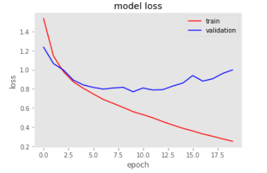

## 40% train data and 60% test -> usually underfits

A statistical model or a machine learning algorithm is said to have underfitting when it cannot capture the underlying trend of the data. Underfitting destroys the accuracy of our machine learning model. Its occurrence simply means that our model or the algorithm does not fit the data well enough. It usually happens when we have less data to build an accurate model and also when we try to build a linear model with a non-linear data. In such cases the rules of the machine learning model are too easy and flexible to be applied on such minimal data and therefore the model will probably make a lot of wrong predictions. Underfitting can be avoided by using more data and also reducing the features by feature selection.

#### Resource: https://www.geeksforgeeks.org/underfitting-and-overfitting-in-machine-learning/

## Linear Regression, 80% train, 20% test

```python
LR = LinearRegression().fit(x_train, y_train)
predition = LR.predict(x_test)
predition_list = predition.tolist()
y_test_list = y_test.tolist()
res_mse = mse(predition_list, y_test_list)
res_rmse = rmse(predition_list, y_test_list)
print("mse: ",res_mse)
print("rmse: ",res_rmse)
```

```
mse:  405531309713080.1
rmse:  20137807.966933247
```

## Linear Regression, 98% train, 2% test

```python
x_2_train, x_2_test, y_2_train, y_2_test = train_test_split(data_cleansed_3_withOut_price, data_cleansed_3['price'], test_size = 0.02)
x_2_train.shape, y_2_train.shape, x_2_test.shape, y_2_test.shape
```

```
((101723, 204), (101723,), (2076, 204), (2076,))
```

```python
LR = LinearRegression().fit(x_2_train, y_2_train)
predition = LR.predict(x_2_test)
predition_list = predition.tolist()
y_2_test_list = y_2_test.tolist()
res_mse = mse(predition_list, y_2_test_list)
res_rmse = rmse(predition_list, y_2_test_list)
print("mse: ",res_mse)
print("rmse: ",res_rmse)
```

```
mse:  317929562380167.44
rmse:  17830579.417959683
```

## Linear Regression, 40% train, 60% test

```python
x_3_train, x_3_test, y_3_train, y_3_test = train_test_split(data_cleansed_3_withOut_price, data_cleansed_3['price'], test_size = 0.6)
x_3_train.shape, y_3_train.shape, x_3_test.shape, y_3_test.shape
```

```
((41519, 204), (41519,), (62280, 204), (62280,))
```

```python
LR = LinearRegression().fit(x_3_train, y_3_train)
predition = LR.predict(x_3_test)
predition_list = predition.tolist()
y_3_test_list = y_3_test.tolist()
res_mse = mse(predition_list, y_3_test_list)
res_rmse = rmse(predition_list, y_3_test_list)
print("mse: ",res_mse)
print("rmse: ",res_rmse)
```

```
mse:  384019171505837.2
rmse:  19596407.10706524
```

#### Conclusion

We can see that for this specific datasets, results have been not quit the way we expected but we have generated 3 different answers that imply that when we take 101723 rows for our dataset, we get the best result.

# Decision Tree

Decision Trees (DTs) are a non-parametric supervised learning method used for classification and regression. The goal is to create a model that predicts the value of a target variable by learning simple decision rules inferred from the data features. A tree can be seen as a piecewise constant approximation.

Decision-tree learners can create over-complex trees that do not generalise the data well. This is called overfitting. Mechanisms such as pruning, setting the minimum number of samples required at a leaf node or setting the maximum depth of the tree are necessary to avoid this problem.

### Question: maximum depth :

```
the number of samples required to populate the tree doubles for each additional level the tree grows to.
```

Effect:

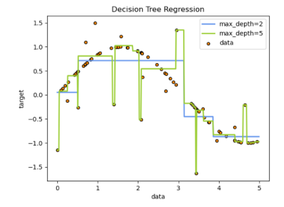

### Question: min_samples_split:

```
We use min_samples_split or min_samples_leaf to ensure that multiple samples inform every decision in the tree, by controlling which splits will be considered.
A very small number will usually mean the tree will overfit, whereas a large number will prevent the tree from learning the data. Try min_samples_leaf=5 as an initial value. If the sample size varies greatly, a float number can be used as percentage in these two parameters.
```

# Question 6:

#### Question: If max_Depth would be too large:

```
If you set max_depth too high, then the decision tree might simply overfit the training data without capturing useful patterns as we would like; this will cause testing error to increase.
```

```
If we set it too low, that is not good as well; then you might be giving the decision tree too little flexibility to capture the patterns and interactions in the training data. This will also cause the testing error to increase.
```

```python
max_Depths = [1, 5, 10, 30, 60, 80, 100, 200]
res_mse_list = []
res_rmse_list = []
for depth in max_Depths:
    dtree = DecisionTreeRegressor(max_depth = depth)
    dtree = dtree.fit(x_train, y_train)
    predition = dtree.predict(x_test)
    predition_list = predition.tolist()
    y_test_list = y_test.tolist()
    res_mse_list.append(mse(predition_list, y_test_list))
    res_rmse_list.append(rmse(predition_list, y_test_list))
```

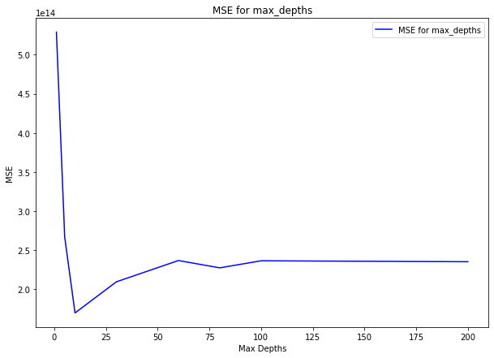

```python
plt.figure(figsize = (10,7))
plt.plot(max_Depths, res_mse_list, color='b', label='MSE for max_depths')
plt.xlabel("Max Depths")
plt.ylabel("MSE")
plt.title("MSE for max_depths")
plt.legend()
plt.show()
```

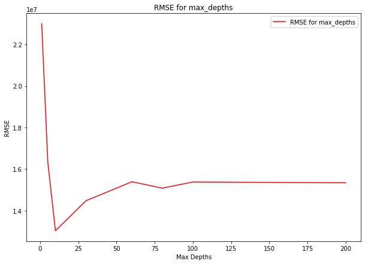

```python
plt.figure(figsize = (10,7))
plt.plot(max_Depths, res_rmse_list, color='r', label='RMSE for max_depths')
plt.xlabel("Max Depths")
plt.ylabel("RMSE")
plt.title("RMSE for max_depths")
plt.legend()
plt.show()
```

We can totally see that everything that has been stated so far is working properly and

- If you set max_depth too high, then the decision tree might simply overfit the training data without capturing useful patterns as we would like; this will cause testing error to increase.
- If we set it too low, that is not good as well; then you might be giving the decision tree too little flexibility to capture the patterns and interactions in the training data. This will also cause the testing error to increase.

# Random Forest

A random forest is a meta estimator that fits a number of classifying decision trees on various sub-samples of the dataset and uses averaging to improve the predictive accuracy and control over-fitting. The sub-sample size is controlled with the max_samples parameter if bootstrap=True (default), otherwise the whole dataset is used to build each tree.

#### Question: max_depth

```
The maximum depth of the tree. If None, then nodes are expanded until all leaves are pure or until all leaves contain less than min_samples_split samples.
```

#### Question n_estimators

```
The number of trees in the forest. By default it is 100
```

```python
max_Depths = [10, 40, 80, 100]
n_estimators = [20, 60, 100, 160]
res_mse_list = []
res_rmse_list = []
for depth in max_Depths:
    for n in n_estimators:
        RF = RandomForestRegressor(max_depth= depth, n_estimators = n)
        RF = RF.fit(x_2_train, y_2_train)
        predition = RF.predict(x_2_test)
        predition_list = predition.tolist()
        y_2_test_list = y_2_test.tolist()
        res_mse_list.append(mse(predition_list, y_2_test_list))
        res_rmse_list.append(rmse(predition_list, y_2_test_list))
```

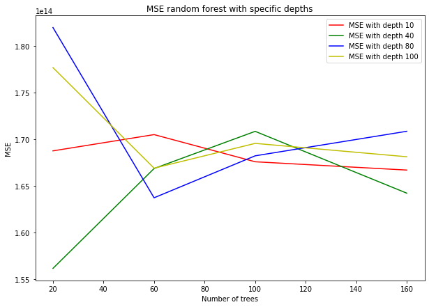

```python
plt.figure(figsize = (10,7))
plt.plot(n_estimators, [res_mse_list[0],res_mse_list[1],res_mse_list[2],res_mse_list[3]], color='r', label='MSE with depth 10')
plt.plot(n_estimators, [res_mse_list[4],res_mse_list[5],res_mse_list[6],res_mse_list[7]], color='g', label='MSE with depth 40')
plt.plot(n_estimators, [res_mse_list[8],res_mse_list[9],res_mse_list[10],res_mse_list[11]], color='b', label='MSE with depth 80')
plt.plot(n_estimators, [res_mse_list[12],res_mse_list[13],res_mse_list[14],res_mse_list[15]], color='y', label='MSE with depth 100')
plt.xlabel("Number of trees")
plt.ylabel("MSE")
plt.title("MSE random forest with specific depths")
plt.legend()
plt.show()
```

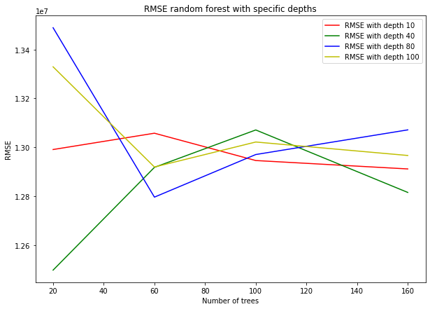

```python
plt.figure(figsize = (10,7))
plt.plot(n_estimators, [res_rmse_list[0],res_rmse_list[1],res_rmse_list[2],res_rmse_list[3]], color='r', label='RMSE with depth 10')
plt.plot(n_estimators, [res_rmse_list[4],res_rmse_list[5],res_rmse_list[6],res_rmse_list[7]], color='g', label='RMSE with depth 40')
plt.plot(n_estimators, [res_rmse_list[8],res_rmse_list[9],res_rmse_list[10],res_rmse_list[11]], color='b', label='RMSE with depth 80')
plt.plot(n_estimators, [res_rmse_list[12],res_rmse_list[13],res_rmse_list[14],res_rmse_list[15]], color='y', label='RMSE with depth 100')
plt.xlabel("Number of trees")
plt.ylabel("RMSE")
plt.title("RMSE random forest with specific depths")
plt.legend()
plt.show()
```

```python
max_Depth = 20
RF = RandomForestRegressor(max_depth= max_Depth, n_estimators = 60)
RF = RF.fit(x_3_train, y_3_train)
predition = RF.predict(x_3_test)
predition_list = predition.tolist()
y_3_test_list = y_3_test.tolist()
res_mse = mse(predition_list, y_3_test_list)
res_rmse = rmse(predition_list, y_3_test_list)
print("mse: ",res_mse)
print("rmse: ",res_rmse)
```

```
mse:  139621862144461.33
rmse:  11816169.52080755
```

```python
max_Depth = 20
RF = RandomForestRegressor(max_depth= max_Depth, n_estimators = 60)
RF = RF.fit(x_train, y_train)
predition = RF.predict(x_test)
predition_list = predition.tolist()
y_test_list = y_test.tolist()
res_mse = mse(predition_list, y_test_list)
res_rmse = rmse(predition_list, y_test_list)
print("mse: ",res_mse)
print("rmse: ",res_rmse)
```

```
mse:  133031615963371.88
rmse:  11533933.239072084
```

```python
max_Depth = 20
RF = RandomForestRegressor(max_depth= max_Depth, n_estimators = 60)
RF = RF.fit(x_2_train, y_2_train)
predition = RF.predict(x_2_test)
predition_list = predition.tolist()
y_2_test_list = y_2_test.tolist()
res_mse = mse(predition_list, y_2_test_list)
res_rmse = rmse(predition_list, y_2_test_list)
print("mse: ",res_mse)
print("rmse: ",res_rmse)
```

```
mse:  107495459223054.47
rmse:  10368001.698642533
```

### We reached about 10M RMSE

# Question 7:

### Question: Bias and deviation Rabdom Forest VS Decision Tree

#### Bias and deviation

```
Bias: Bias is the difference between the average prediction of our model and the correct value which we are trying to predict.

Variance: Variance is the variability of model prediction for a given data point or a value which tells us spread of our data. Model with high variance pays a lot of attention to training data and does not generalize on the data which it hasn’t seen before.
```

#### Bias and deviation Rabdom Forest VS Decision Tree

```
An algorithm like Decision Tree has low bias but high variance, because it can easily change as small change in input variable. In general, it does not generalize the pattern well. It leads to overfitting.

random forest use each tree's high variance models and aggregate them in order to reduce variance and thus enhance prediction accuracy. Both Bagging and Random Forests use Bootstrap sampling, and as described in "Elements of Statistical Learning", this increases bias in the single tree.
```

#### Conclusion:

```
 random forests are a strong modeling technique and much more robust than a single decision tree. They aggregate many decision trees to limit overfitting as well as error due to bias and therefore yield useful results.

 And yes we can see that our model is acting the same way theory says, Random Forest showed a stronger algorithm.
 In this algorithm we almost reached 10M of RMSE
```

```python
!jt -t grade3 -T -N -kl
```